# A3_Tadepalli_Sai_Eshwar

Sai Eshwar Tadepalli

2023-06-07

## 1 - Set up, Data import, and Preparation

1A. Package loading, and data import. Set the working directory to the directory where your rmarkdown program file resides in rstudio using getwd() and setwd(). For example,

mydir <- getwd() setwd(mydir)

Now that you are familiar with the variables in the input data, feel free to load character variables as factors in read.csv(). Show the overall structure and summary of the data frame that keeps the data from the input file.

```r
# Load packages
library(e1071)
library(C50)
library(caret)
```

```r
library(rminer)
library(rmarkdown)
library(matrixStats)
library(knitr)
library(tictoc)
tic()

# Import titanic_cleaned.csv file
cloud_wd <- getwd()
setwd(cloud_wd)

balanced <- read.csv(file = "CD_additional_modified.csv", stringsAsFactors = TRUE)

### Examine the overall data frame
str(balanced)
```

```
## 'data.frame':    4119 obs. of  21 variables:
##  $ age           : int  30 39 25 38 47 32 32 41 31 35 ...
##  $ job           : Factor w/ 12 levels "admin.","blue-collar",..: 2 8 8 8 1 8 1 3 8 2 ...
##  $ marital       : Factor w/ 4 levels "divorced","married",..: 2 3 2 2 2 3 3 2 1 2 ...
##  $ education     : Factor w/ 8 levels "basic.4y","basic.6y",..: 3 4 4 3 7 7 7 7 6 3 ...
##  $ default       : Factor w/ 3 levels "no","unknown",..: 1 1 1 1 1 1 1 2 1 2 ...
##  $ housing       : Factor w/ 3 levels "no","unknown",..: 3 1 3 2 3 1 3 3 1 1 ...
##  $ loan          : Factor w/ 3 levels "no","unknown",..: 1 1 1 2 1 1 1 1 1 1 ...
##  $ contact       : Factor w/ 2 levels "cellular","telephone": 1 2 2 2 1 1 1 1 1 2 ...
##  $ month         : Factor w/ 10 levels "apr","aug","dec",..: 7 7 5 5 8 10 10 8 8 7 ...
##  $ day_of_week   : Factor w/ 5 levels "fri","mon","thu",..: 1 1 5 1 2 3 2 2 4 3 ...
##  $ duration      : int  487 346 227 17 58 128 290 44 68 170 ...
##  $ campaign      : int  2 4 1 3 1 3 4 2 1 1 ...
##  $ pdays         : int  999 999 999 999 999 999 999 999 999 999 ...
##  $ previous      : int  0 0 0 0 0 2 0 0 1 0 ...
##  $ poutcome      : Factor w/ 3 levels "failure","nonexistent",..: 2 2 2 2 2 1 2 2 1 2 ...
##  $ emp.var.rate  : num  -1.8 1.1 1.4 1.4 -0.1 -1.1 -1.1 -0.1 -0.1 1.1 ...
##  $ cons.price.idx: num  92.9 94 94.5 94.5 93.2 ...
##  $ cons.conf.idx : num  -46.2 -36.4 -41.8 -41.8 -42 -37.5 -37.5 -42 -42 -36.4 ...
##  $ euribor3m     : num  1.31 4.86 4.96 4.96 4.19 ...
##  $ nr.employed   : num  5099 5191 5228 5228 5196 ...
##  $ y             : Factor w/ 2 levels "no","yes": 1 1 1 1 1 1 1 1 1 1 ...
```

```r
summary(balanced)
```

```
##       age                 job           marital                   education
##  Min.   :18.00   admin.     :1012   divorced: 446   university.degree  :1264
##  1st Qu.:32.00   blue-collar: 884   married :2509   high.school        : 921
##  Median :38.00   technician : 691   single  :1153   basic.9y           : 574
##  Mean   :40.11   services   : 393   unknown :  11   professional.course: 535
##  3rd Qu.:47.00   management : 324                   basic.4y           : 429
##  Max.   :88.00   retired    : 166                   basic.6y           : 228
##                  (Other)    : 649                   (Other)            : 168
##     default        housing          loan           contact         month
##  no     :3315   no     :1839   no     :3349   cellular :2652   may    :1378
##  unknown: 803   unknown: 105   unknown: 105   telephone:1467   jul    : 711
##  yes    :   1   yes    :2175   yes    : 665                    aug    : 636
##                                                                jun    : 530
##                                                                nov    : 446
##                                                                apr    : 215
##                                                                (Other): 203
##  day_of_week    duration         campaign          pdays          previous
##  fri:768     Min.   :   0.0   Min.   : 1.000   Min.   :  0.0   Min.   :0.0000
##  mon:855     1st Qu.: 103.0   1st Qu.: 1.000   1st Qu.:999.0   1st Qu.:0.0000
##  thu:860     Median : 181.0   Median : 2.000   Median :999.0   Median :0.0000
##  tue:841     Mean   : 256.8   Mean   : 2.537   Mean   :960.4   Mean   :0.1903
##  wed:795     3rd Qu.: 317.0   3rd Qu.: 3.000   3rd Qu.:999.0   3rd Qu.:0.0000
##              Max.   :3643.0   Max.   :35.000   Max.   :999.0   Max.   :6.0000
##
##         poutcome     emp.var.rate      cons.price.idx  cons.conf.idx
##  failure    : 454   Min.   :-3.40000   Min.   :92.20   Min.   :-50.8
##  nonexistent:3523   1st Qu.:-1.80000   1st Qu.:93.08   1st Qu.:-42.7
##  success    : 142   Median : 1.10000   Median :93.75   Median :-41.8
##                     Mean   : 0.08497   Mean   :93.58   Mean   :-40.5
##                     3rd Qu.: 1.40000   3rd Qu.:93.99   3rd Qu.:-36.4
##                     Max.   : 1.40000   Max.   :94.77   Max.   :-26.9
##
##    euribor3m      nr.employed     y
##  Min.   :0.635   Min.   :4964   no :3668
##  1st Qu.:1.334   1st Qu.:5099   yes: 451
##  Median :4.857   Median :5191
##  Mean   :3.621   Mean   :5166
##  3rd Qu.:4.961   3rd Qu.:5228
##  Max.   :5.045   Max.   :5228
##
```

```r
# setting seed to a value for createDataPartition().
set.seed(100)
inTrain <- createDataPartition(iris$Species, p=0.7, list=FALSE)

# Assigning the rows in CD Additional Modified indexed by inTrain to create a train set
# Assign all other rows indexed by -inTrain to create a test set

balancedTrain <- balanced[inTrain,]
balancedTest <- balanced[-inTrain,]
```

1C. Show the distributions (in percentages) of the target variable in the whole input data frame, the train set and the test set.

```r
# Percentage distribution of target variable in the whole input data frame
prop.table(table(balanced$y))*100
```

```
##
##       no      yes
## 89.05074 10.94926
```

```r
# Percentage distribution of target variable in the train set
prop.table(table(balancedTrain$y))*100
```

```
##
##       no      yes
## 90.47619  9.52381
```

```r
# Percentage distribution of target variable in the test set
prop.table(table(balancedTest$y))*100
```

```
##
##       no      yes
## 89.01345 10.98655
```

## 2 - Simple Decision Tree Training and Testing

(Note: Here, you are repeating the code for the same task in Assignment 2 in order to examine the models and performance results for a different data set):

2A. (10 points) Train a C5.0 model using the default setting. Show information about this model and the summary of the model. Do not plot the tree at this point because the tree might be too complex. Generate and compare this model’s confusion matrices and classification evaluation metrics in testing and training sets

```r
# Using the train set to build a model
balanced_m1_c50 <- C5.0(y~., balancedTrain)
balanced_m1_c50
```

```
##
## Call:
## C5.0.formula(formula = y ~ ., data = balancedTrain)
##
## Classification Tree
## Number of samples: 105
## Number of predictors: 20
##
## Tree size: 1
##
## Non-standard options: attempt to group attributes
```

```r
summary(balanced_m1_c50)
```

```
##
## Call:
## C5.0.formula(formula = y ~ ., data = balancedTrain)
##
##
## C5.0 [Release 2.07 GPL Edition]      Tue Jun  6 20:04:55 2023
## -------------------------------
##
## Class specified by attribute `outcome'
##
## Read 105 cases (21 attributes) from undefined.data
##
## Decision tree:
##  no (105/10)
##
##
## Evaluation on training data (105 cases):
##
##      Decision Tree
##    ----------------
##    Size      Errors
##
##       1   10( 9.5%)   <<
##
##
##     (a)   (b)    <-classified as
##    ----  ----
##      95          (a): class no
##      10          (b): class yes
##
##
## Time: 0.0 secs
```

```r
# Applying the model to the hold-out test set and generate holdout evaluation metrics

predicted_y_test1 <- predict(balanced_m1_c50, balancedTest)
mmetric(balancedTest$y, predicted_y_test1, metric="CONF")
```

```
## $res
## NULL
##
## $conf
##       pred
## target   no  yes
##    no  3573    0
##    yes  441    0
##
## $roc
## NULL
##
## $lift
## NULL
```

```r
mmetric(balancedTest$y, predicted_y_test1, metric=c("ACC","TPR","PRECISION","F1"))
```

```
##        ACC       TPR1       TPR2 PRECISION1 PRECISION2        F11        F12
##   89.01345  100.00000    0.00000   89.01345    0.00000   94.18743    0.00000
```

```r
# For comparison, applying the model to the train set and generate evaluation metrics.
# Check out the performance drop in the holdout set.
predicted_y_train1 <- predict(balanced_m1_c50, balancedTrain)
mmetric(balancedTrain$y, predicted_y_train1, metric="CONF")
```

```
## $res
## NULL
##
## $conf
##       pred
## target no yes
##    no  95   0
##    yes 10   0
##
## $roc
## NULL
##
## $lift
## NULL
```

```r
mmetric(balancedTrain$y, predicted_y_train1, metric=c("ACC","TPR","PRECISION","F1"))
```

```
##        ACC       TPR1       TPR2 PRECISION1 PRECISION2        F11        F12
##   90.47619  100.00000    0.00000   90.47619    0.00000   95.00000    0.00000
```

2B. (10 points) Explore reducing the tree complexity by lowering CF levels. In the code, select a CF level of your choice to train and test another C5.0 model. Plot the tree. Generate and compare this model’s confusion matrices and classification evaluation metrics in testing and training sets

```r
balanced_m2_c50 <- C5.0(y~., balancedTrain, control = C5.0Control(CF = 0.0000005))
balanced_m2_c50
```

```
##
## Call:
## C5.0.formula(formula = y ~ ., data = balancedTrain, control = C5.0Control(CF
##  = 5e-07))
##
## Classification Tree
## Number of samples: 105
## Number of predictors: 20
##
## Tree size: 1
##
## Non-standard options: attempt to group attributes, confidence level: 5e-07
```

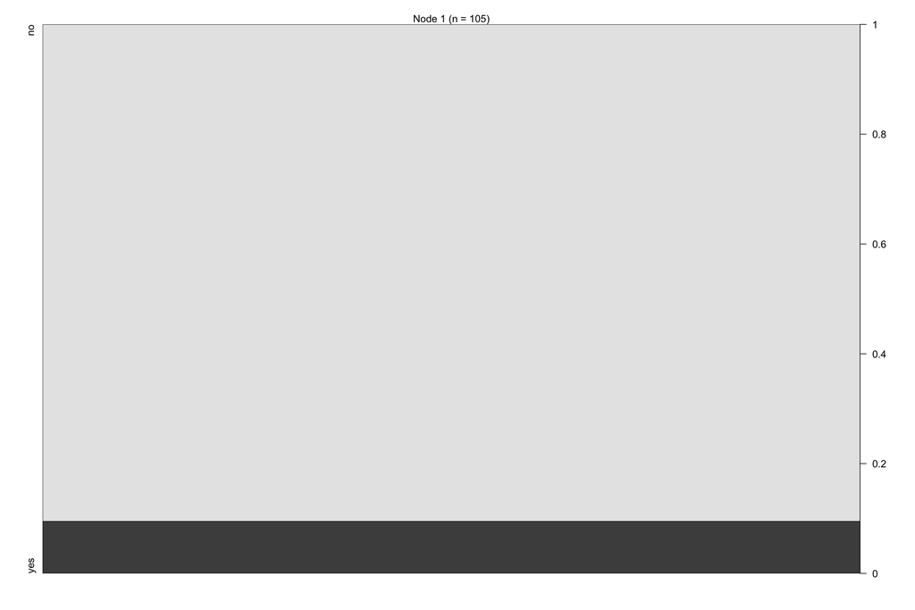

```r
plot(balanced_m2_c50)
```

```r
summary(balanced_m2_c50)
```

```
##
## Call:
## C5.0.formula(formula = y ~ ., data = balancedTrain, control = C5.0Control(CF
##  = 5e-07))
##
##
## C5.0 [Release 2.07 GPL Edition]      Tue Jun  6 20:04:55 2023
## -------------------------------
##
## Class specified by attribute `outcome'
##
## Read 105 cases (21 attributes) from undefined.data
##
## Decision tree:
##  no (105/10)
##
##
## Evaluation on training data (105 cases):
##
##      Decision Tree
##    ----------------
##    Size      Errors
##
##       1   10( 9.5%)   <<
##
##
##     (a)   (b)    <-classified as
##    ----  ----
##      95          (a): class no
##      10          (b): class yes
##
##
## Time: 0.0 secs
```

```r
predicted_y_test2 <- predict(balanced_m2_c50, balancedTest)

mmetric(balancedTest$y, predicted_y_test2, metric="CONF")
```

```
## $res
## NULL
##
## $conf
##       pred
## target   no  yes
##    no  3573    0
##    yes  441    0
##
## $roc
## NULL
##
## $lift
## NULL
```

```r
mmetric(balancedTest$y, predicted_y_test2, metric=c("ACC","TPR","PRECISION","F1"))
```

```
##        ACC       TPR1       TPR2 PRECISION1 PRECISION2        F11        F12
##   89.01345  100.00000    0.00000   89.01345    0.00000   94.18743    0.00000
```

```r
predicted_y_train2 <- predict(balanced_m2_c50, balancedTrain)

mmetric(balancedTrain$y, predicted_y_train2, metric="CONF")
```

```
## $res
## NULL
##
## $conf
##       pred
## target no yes
##    no  95   0
##    yes 10   0
##
## $roc
## NULL
##
## $lift
## NULL
```

```r
mmetric(balancedTrain$y, predicted_y_train2, metric=c("ACC","TPR","PRECISION","F1"))
```

```
##        ACC       TPR1       TPR2 PRECISION1 PRECISION2        F11        F12
##   90.47619  100.00000    0.00000   90.47619    0.00000   95.00000    0.00000
```